# The studentized complement field (field-s) on six identifier cells: naive / field / field-s / IJ two-term on identical replicates

- Show All Code
- Hide All Code
- View Source

Campaign e1stud against the committed comparators (p30sgnb20, banddial); TASK_field_studentize_e1_2026-09-08 (R1); transplanted from summary_banddial.qmd

Author

Larry León

Published

September 8, 2026

Six cells of the J = 10 harm design (31% prevalence, n = 500, seeds 8316951 + sim_id): `effMaxSG` at ε = 0.20 (HR 1.50 / 1.75; comparator nb20 arm A `p30sgnb20`), `effMaxSG` at ε = 0.30 (both HRs; comparator `banddial`; a mapped stress comparator only, under the ε ≤ 0.25 cap), `maxSG` and `minSG` (HR 1.75; comparator `banddial`). The `e1stud` bundles re-run every cell with `field_decompose = TRUE` and `field_scale_complement = "selected"`: every pre-existing column is `identical()` to its committed comparator (the pairing proof, asserted below and in the per-cell Gate 2 records), and the studentized complement field (“field-s”, the percentile-t root `(s_sel/s_G) ζᶜ_{r,G} − mean_j (s_sel/s_{G_j}) ζ'ᶜ_{j,G_j}`) is added beside the unscaled one. Constructions on both blocks: naive (reference), MR (IJ two-term), MR (field), MR (field-s) — the harm block is untouched by construction, so field-s = field there; winner-only and winner-floor excluded. “SD units” and “SD(β̃ᶜ)/naive SE” follow the reports’ convention (marginal SD of the log estimate); the error-scale SD (`REPORT_complement_variance_2026-09-07`, A0) is shown beside it.

# 1 Bundles and the pairing identity

```r
library(forestsearch)
library(ggplot2)
library(kableExtra)
`%||%` <- function(a, b) if (is.null(a) || length(a) == 0 || all(is.na(a))) b else a
cells <- list(
  list(key = "eps20_h150", label = "effMaxSG eps 0.20, HR 1.50", kind = "band",
       comp = "results/fs_effMaxSG_fb_mr_field_m1_h150_knoise0_n500_z1q60_nb20_p30sgnb20_combined_1_2000.rds",
       e1   = "results/fs_effMaxSG_fb_mr_field_m1_h150_knoise0_n500_z1q60_nb20_e1stud_combined_1_2000.rds"),
  list(key = "eps20_h175", label = "effMaxSG eps 0.20, HR 1.75", kind = "band",
       comp = "results/fs_effMaxSG_fb_mr_field_m1_h175_knoise0_n500_z1q60_nb20_p30sgnb20_combined_1_2000.rds",
       e1   = "results/fs_effMaxSG_fb_mr_field_m1_h175_knoise0_n500_z1q60_nb20_e1stud_combined_1_2000.rds"),
  list(key = "eps30_h150", label = "effMaxSG eps 0.30 (stress), HR 1.50", kind = "band",
       comp = "results/fs_effMaxSG_fb_mr_field_m1_h150_knoise0_n500_z1q60_nb30_banddial_combined_1_2000.rds",
       e1   = "results/fs_effMaxSG_fb_mr_field_m1_h150_knoise0_n500_z1q60_nb30_e1stud_combined_1_2000.rds"),
  list(key = "eps30_h175", label = "effMaxSG eps 0.30 (stress), HR 1.75", kind = "band",
       comp = "results/fs_effMaxSG_fb_mr_field_m1_h175_knoise0_n500_z1q60_nb30_banddial_combined_1_2000.rds",
       e1   = "results/fs_effMaxSG_fb_mr_field_m1_h175_knoise0_n500_z1q60_nb30_e1stud_combined_1_2000.rds"),
  list(key = "maxSG_h175", label = "maxSG, HR 1.75", kind = "end",
       comp = "results/fs_maxSG_fb_mr_field_m1_h175_knoise0_n500_z1q60_banddial_combined_1_2000.rds",
       e1   = "results/fs_maxSG_fb_mr_field_m1_h175_knoise0_n500_z1q60_e1stud_combined_1_2000.rds"),
  list(key = "minSG_h175", label = "minSG, HR 1.75", kind = "end",
       comp = "results/fs_minSG_fb_mr_field_m1_h175_knoise0_n500_z1q60_banddial_combined_1_2000.rds",
       e1   = "results/fs_minSG_fb_mr_field_m1_h175_knoise0_n500_z1q60_e1stud_combined_1_2000.rds"))
timing_cols <- c("fb_secs", "fit_mr_secs", "fld_H_secs", "fld_Hc_secs", "fld_H_uniform_secs")
B <- lapply(cells, function(cl) if (file.exists(cl$e1) && file.exists(cl$comp)) list(e1 = readRDS(cl$e1), comp = readRDS(cl$comp)) else NULL)
names(B) <- vapply(cells, `[[`, "", "key")
labs <- setNames(vapply(cells, `[[`, "", "label"), names(B))
kind <- setNames(vapply(cells, `[[`, "", "kind"), names(B))
pair <- do.call(rbind, lapply(names(B), function(k) { b <- B[[k]]
  if (is.null(b)) return(data.frame(cell = labs[[k]], present = FALSE, n_rows = NA, identical_cols = NA, of = NA, truth_identical = NA, n_detected = NA))
  rc <- b$comp$results; rf <- b$e1$results; rc <- rc[order(rc$sim_id), ]; rf <- rf[order(rf$sim_id), ]
  pre <- setdiff(names(rc), timing_cols); id <- vapply(pre, function(cn) identical(rc[[cn]], rf[[cn]]), TRUE)
  data.frame(cell = labs[[k]], present = TRUE, n_rows = nrow(rf), identical_cols = sum(id), of = length(pre),
             truth_identical = identical(b$comp$truth, b$e1$truth), n_detected = sum(rf$detected %in% 1L)) }))
kbl(pair, booktabs = TRUE, row.names = FALSE, caption = "Bundles read; the pairing identity: every pre-existing non-timing column of the e1stud bundle identical() to the committed comparator's, truth identical.") |> kable_styling(font_size = 11)
```

Bundles read; the pairing identity: every pre-existing non-timing column of the e1stud bundle identical() to the committed comparator's, truth identical.

| cell | present | n_rows | identical_cols | of | truth_identical | n_detected |
| --- | --- | --- | --- | --- | --- | --- |
| effMaxSG eps 0.20, HR 1.50 | TRUE | 2000 | 131 | 131 | TRUE | 1999 |
| effMaxSG eps 0.20, HR 1.75 | TRUE | 2000 | 131 | 131 | TRUE | 1999 |
| effMaxSG eps 0.30 (stress), HR 1.50 | TRUE | 2000 | 131 | 131 | TRUE | 1999 |
| effMaxSG eps 0.30 (stress), HR 1.75 | TRUE | 2000 | 131 | 131 | TRUE | 1999 |
| maxSG, HR 1.75 | TRUE | 2000 | 131 | 131 | TRUE | 1999 |
| minSG, HR 1.75 | TRUE | 2000 | 131 | 131 | TRUE | 1999 |

```r
B <- B[!vapply(B, is.null, TRUE)]
```

# 2 Constructions on both blocks: naive / field / field-s / IJ two-term (identical replicates)

```r
# field-s rows come from the same function on a column-substituted copy of the results
# (fld_Hc_* <- fld_Hc_*_s); the harm block has no _s twin (field-s = field there by construction).
subst_s <- function(r) { for (s in c("est2", "up1s", "lo1s", "lo2s", "hi2s", "lo_se", "hi_se", "se", "lam_mean")) r[[paste0("fld_Hc_", s)]] <- r[[paste0("fld_Hc_", s, "_s")]]; r }
err_sd <- function(r, block, est) { d <- r[r$detected %in% 1L, ]
  e <- switch(est, naive = d[[paste0("nv_", block, "_est")]], mr = d[[paste0("mr_", block, "_est")]], fld = d[[paste0("fld_", block, "_est2")]])
  ok <- is.finite(e) & is.finite(d[[paste0("betaHhat_", block)]]); sd(log(e[ok]) - log(d[[paste0("betaHhat_", block)]][ok])) }
cov_block <- function(r, block, side) {
  t1 <- fs_sim_bias_coverage(r, block = block, estimators = c("naive", "mr", "fld"), side = side)
  t1$sd_err <- vapply(as.character(t1$estimator), function(e) err_sd(r, block, e), 0)
  t1$construction <- c(naive = "naive", mr = "IJ two-term", fld = "field")[as.character(t1$estimator)]
  if (block == "Hc") { rs <- subst_s(r); t2 <- fs_sim_bias_coverage(rs, block = "Hc", estimators = "fld", side = side)
    t2$sd_err <- err_sd(rs, "Hc", "fld"); t2$construction <- "field-s"; t1 <- rbind(t1, t2) }
  t1$se_over_sd_err <- t1$se_mean / t1$sd_err
  t1 }
COV <- do.call(rbind, lapply(names(B), function(k) { r <- B[[k]]$e1$results
  rbind(cbind(cell = labs[[k]], block = "Hhat (lower)", cov_block(r, "H", "lower")),
        cbind(cell = labs[[k]], block = "Hhat^c (upper)", cov_block(r, "Hc", "upper"))) }))
COV$construction <- factor(COV$construction, levels = c("naive", "field", "field-s", "IJ two-term"))
COV <- COV[order(match(COV$cell, labs), COV$block, COV$construction), ]
kbl(COV[, c("cell", "block", "construction", "n", "bias_log", "sd_emp", "sd_err", "se_mean", "b", "r", "se_over_sd_err", "cov1", "cov1_wilson_lo", "cov1_wilson_hi", "cov2", "cov1_ref")],
    digits = 3, booktabs = TRUE, row.names = FALSE,
    caption = "Per cell: bias (log), marginal SD (sd_emp), error-scale SD (sd_err = SD of log est - log target), mean SE, b = bias / marginal SD, r = mean SE / marginal SD, SE / error SD; cov1 = one-sided 95% coverage of beta(Hhat) by the lower bound / of beta(Hhat^c) by the upper bound with Wilson limits; cov2 = two-sided; cov1_ref = Gaussian reference. The harm block has no field-s row: it is untouched by construction.") |>
  kable_styling(font_size = 10)
```

Per cell: bias (log), marginal SD (sd_emp), error-scale SD (sd_err = SD of log est - log target), mean SE, b = bias / marginal SD, r = mean SE / marginal SD, SE / error SD; cov1 = one-sided 95% coverage of beta(Hhat) by the lower bound / of beta(Hhat^c) by the upper bound with Wilson limits; cov2 = two-sided; cov1_ref = Gaussian reference. The harm block has no field-s row: it is untouched by construction.

| cell | block | construction | n | bias_log | sd_emp | sd_err | se_mean | b | r | se_over_sd_err | cov1 | cov1_wilson_lo | cov1_wilson_hi | cov2 | cov1_ref |
| --- | --- | --- | --- | --- | --- | --- | --- | --- | --- | --- | --- | --- | --- | --- | --- |
| effMaxSG eps 0.20, HR 1.50 | Hhat (lower) | naive | 1999 | 0.430 | 0.238 | 0.281 | 0.250 | 1.809 | 1.049 | 0.887 | 0.484 | 0.462 | 0.506 | 0.619 | 0.467 |
| effMaxSG eps 0.20, HR 1.50 | Hhat (lower) | field | 1999 | -0.056 | 0.299 | 0.314 | 0.324 | -0.185 | 1.081 | 1.029 | 0.974 | 0.967 | 0.981 | 0.925 | 0.975 |
| effMaxSG eps 0.20, HR 1.50 | Hhat (lower) | IJ two-term | 1999 | -0.003 | 0.279 | 0.303 | 0.360 | -0.011 | 1.289 | 1.186 | 0.985 | 0.979 | 0.990 | 0.981 | 0.983 |
| effMaxSG eps 0.20, HR 1.50 | Hhat^c (upper) | naive | 1999 | -0.123 | 0.156 | 0.143 | 0.143 | -0.789 | 0.912 | 0.997 | 0.781 | 0.762 | 0.798 | 0.849 | 0.762 |
| effMaxSG eps 0.20, HR 1.50 | Hhat^c (upper) | field | 1999 | -0.031 | 0.159 | 0.147 | 0.135 | -0.193 | 0.852 | 0.923 | 0.897 | 0.883 | 0.910 | 0.921 | 0.886 |
| effMaxSG eps 0.20, HR 1.50 | Hhat^c (upper) | field-s | 1999 | -0.031 | 0.159 | 0.147 | 0.142 | -0.194 | 0.896 | 0.970 | 0.912 | 0.899 | 0.924 | 0.938 | 0.900 |
| effMaxSG eps 0.20, HR 1.50 | Hhat^c (upper) | IJ two-term | 1999 | -0.044 | 0.157 | 0.145 | 0.257 | -0.282 | 1.636 | 1.776 | 0.995 | 0.991 | 0.997 | 1.000 | 0.992 |
| effMaxSG eps 0.20, HR 1.75 | Hhat (lower) | naive | 1999 | 0.365 | 0.246 | 0.294 | 0.243 | 1.481 | 0.985 | 0.825 | 0.573 | 0.551 | 0.595 | 0.694 | 0.555 |
| effMaxSG eps 0.20, HR 1.75 | Hhat (lower) | field | 1999 | -0.078 | 0.312 | 0.329 | 0.323 | -0.251 | 1.035 | 0.983 | 0.970 | 0.962 | 0.977 | 0.911 | 0.975 |
| effMaxSG eps 0.20, HR 1.75 | Hhat (lower) | IJ two-term | 1999 | -0.037 | 0.291 | 0.317 | 0.356 | -0.129 | 1.227 | 1.125 | 0.985 | 0.979 | 0.989 | 0.972 | 0.984 |
| effMaxSG eps 0.20, HR 1.75 | Hhat^c (upper) | naive | 1999 | -0.102 | 0.162 | 0.144 | 0.143 | -0.631 | 0.884 | 0.991 | 0.826 | 0.809 | 0.842 | 0.880 | 0.795 |
| effMaxSG eps 0.20, HR 1.75 | Hhat^c (upper) | field | 1999 | -0.019 | 0.165 | 0.149 | 0.136 | -0.116 | 0.822 | 0.911 | 0.912 | 0.899 | 0.924 | 0.918 | 0.892 |
| effMaxSG eps 0.20, HR 1.75 | Hhat^c (upper) | field-s | 1999 | -0.019 | 0.165 | 0.149 | 0.143 | -0.117 | 0.868 | 0.961 | 0.919 | 0.907 | 0.931 | 0.933 | 0.905 |
| effMaxSG eps 0.20, HR 1.75 | Hhat^c (upper) | IJ two-term | 1999 | -0.030 | 0.163 | 0.147 | 0.258 | -0.183 | 1.586 | 1.761 | 0.995 | 0.991 | 0.998 | 0.999 | 0.992 |
| effMaxSG eps 0.30 (stress), HR 1.50 | Hhat (lower) | naive | 1999 | 0.299 | 0.224 | 0.244 | 0.213 | 1.332 | 0.949 | 0.873 | 0.633 | 0.612 | 0.654 | 0.735 | 0.590 |
| effMaxSG eps 0.30 (stress), HR 1.50 | Hhat (lower) | field | 1999 | -0.093 | 0.270 | 0.267 | 0.298 | -0.344 | 1.103 | 1.116 | 0.980 | 0.973 | 0.986 | 0.937 | 0.985 |
| effMaxSG eps 0.30 (stress), HR 1.50 | Hhat (lower) | IJ two-term | 1999 | -0.068 | 0.254 | 0.258 | 0.334 | -0.266 | 1.311 | 1.294 | 0.995 | 0.991 | 0.997 | 0.987 | 0.992 |
| effMaxSG eps 0.30 (stress), HR 1.50 | Hhat^c (upper) | naive | 1999 | -0.137 | 0.162 | 0.153 | 0.153 | -0.844 | 0.944 | 1.001 | 0.774 | 0.755 | 0.792 | 0.854 | 0.761 |
| effMaxSG eps 0.30 (stress), HR 1.50 | Hhat^c (upper) | field | 1999 | -0.031 | 0.167 | 0.156 | 0.141 | -0.187 | 0.845 | 0.900 | 0.904 | 0.890 | 0.916 | 0.916 | 0.886 |
| effMaxSG eps 0.30 (stress), HR 1.50 | Hhat^c (upper) | field-s | 1999 | -0.032 | 0.167 | 0.157 | 0.152 | -0.190 | 0.915 | 0.974 | 0.921 | 0.909 | 0.932 | 0.936 | 0.906 |
| effMaxSG eps 0.30 (stress), HR 1.50 | Hhat^c (upper) | IJ two-term | 1999 | -0.047 | 0.164 | 0.154 | 0.266 | -0.289 | 1.625 | 1.726 | 0.996 | 0.992 | 0.998 | 1.000 | 0.991 |
| effMaxSG eps 0.30 (stress), HR 1.75 | Hhat (lower) | naive | 1999 | 0.254 | 0.239 | 0.254 | 0.210 | 1.065 | 0.879 | 0.825 | 0.680 | 0.660 | 0.700 | 0.777 | 0.648 |
| effMaxSG eps 0.30 (stress), HR 1.75 | Hhat (lower) | field | 1999 | -0.097 | 0.286 | 0.277 | 0.297 | -0.339 | 1.038 | 1.074 | 0.976 | 0.968 | 0.982 | 0.925 | 0.980 |
| effMaxSG eps 0.30 (stress), HR 1.75 | Hhat (lower) | IJ two-term | 1999 | -0.082 | 0.271 | 0.268 | 0.333 | -0.303 | 1.231 | 1.243 | 0.994 | 0.990 | 0.997 | 0.978 | 0.990 |
| effMaxSG eps 0.30 (stress), HR 1.75 | Hhat^c (upper) | naive | 1999 | -0.113 | 0.164 | 0.153 | 0.152 | -0.691 | 0.928 | 0.996 | 0.807 | 0.790 | 0.824 | 0.875 | 0.798 |
| effMaxSG eps 0.30 (stress), HR 1.75 | Hhat^c (upper) | field | 1999 | -0.021 | 0.171 | 0.158 | 0.141 | -0.123 | 0.828 | 0.894 | 0.903 | 0.890 | 0.916 | 0.914 | 0.892 |
| effMaxSG eps 0.30 (stress), HR 1.75 | Hhat^c (upper) | field-s | 1999 | -0.022 | 0.171 | 0.158 | 0.153 | -0.127 | 0.894 | 0.965 | 0.919 | 0.906 | 0.930 | 0.941 | 0.910 |
| effMaxSG eps 0.30 (stress), HR 1.75 | Hhat^c (upper) | IJ two-term | 1999 | -0.033 | 0.167 | 0.155 | 0.268 | -0.198 | 1.600 | 1.723 | 0.996 | 0.993 | 0.998 | 0.999 | 0.993 |
| maxSG, HR 1.75 | Hhat (lower) | naive | 1999 | 0.046 | 0.063 | 0.095 | 0.133 | 0.739 | 2.118 | 1.400 | 0.947 | 0.936 | 0.956 | 0.974 | 0.997 |
| maxSG, HR 1.75 | Hhat (lower) | field | 1999 | -0.005 | 0.087 | 0.131 | 0.126 | -0.056 | 1.455 | 0.961 | 0.947 | 0.936 | 0.956 | 0.956 | 0.993 |
| maxSG, HR 1.75 | Hhat (lower) | IJ two-term | 1999 | 0.002 | 0.080 | 0.123 | 0.221 | 0.025 | 2.773 | 1.799 | 0.999 | 0.997 | 1.000 | 0.996 | 1.000 |
| maxSG, HR 1.75 | Hhat^c (upper) | naive | 1999 | -0.191 | 0.393 | 0.406 | 0.355 | -0.487 | 0.903 | 0.876 | 0.776 | 0.757 | 0.794 | 0.844 | 0.841 |
| maxSG, HR 1.75 | Hhat^c (upper) | field | 1999 | -0.041 | 0.392 | 0.395 | 0.361 | -0.104 | 0.921 | 0.915 | 0.925 | 0.913 | 0.936 | 0.940 | 0.921 |
| maxSG, HR 1.75 | Hhat^c (upper) | field-s | 1999 | -0.039 | 0.393 | 0.395 | 0.358 | -0.100 | 0.912 | 0.906 | 0.926 | 0.914 | 0.937 | 0.940 | 0.919 |
| maxSG, HR 1.75 | Hhat^c (upper) | IJ two-term | 1999 | -0.064 | 0.389 | 0.394 | 0.621 | -0.164 | 1.598 | 1.576 | 0.995 | 0.991 | 0.997 | 0.999 | 0.993 |
| minSG, HR 1.75 | Hhat (lower) | naive | 1999 | 0.326 | 0.217 | 0.272 | 0.320 | 1.504 | 1.476 | 1.177 | 0.804 | 0.786 | 0.821 | 0.881 | 0.822 |
| minSG, HR 1.75 | Hhat (lower) | field | 1999 | 0.022 | 0.284 | 0.326 | 0.315 | 0.078 | 1.110 | 0.967 | 0.936 | 0.924 | 0.946 | 0.922 | 0.960 |
| minSG, HR 1.75 | Hhat (lower) | IJ two-term | 1999 | 0.074 | 0.258 | 0.305 | 0.391 | 0.288 | 1.514 | 1.280 | 0.971 | 0.963 | 0.977 | 0.985 | 0.986 |
| minSG, HR 1.75 | Hhat^c (upper) | naive | 1999 | -0.049 | 0.139 | 0.136 | 0.130 | -0.350 | 0.932 | 0.958 | 0.879 | 0.864 | 0.893 | 0.924 | 0.882 |
| minSG, HR 1.75 | Hhat^c (upper) | field | 1999 | -0.013 | 0.137 | 0.134 | 0.129 | -0.094 | 0.940 | 0.967 | 0.929 | 0.917 | 0.940 | 0.940 | 0.927 |
| minSG, HR 1.75 | Hhat^c (upper) | field-s | 1999 | -0.013 | 0.137 | 0.134 | 0.130 | -0.094 | 0.945 | 0.972 | 0.929 | 0.917 | 0.939 | 0.943 | 0.928 |
| minSG, HR 1.75 | Hhat^c (upper) | IJ two-term | 1999 | -0.019 | 0.137 | 0.134 | 0.251 | -0.139 | 1.830 | 1.881 | 0.997 | 0.994 | 0.999 | 1.000 | 0.998 |

```r
ACR <- do.call(rbind, lapply(split(COV, list(COV$block, COV$construction), drop = TRUE), function(d)
  data.frame(block = d$block[1], construction = d$construction[1], cells = nrow(d), cov1_min = min(d$cov1), cov1_mean = mean(d$cov1), cov1_max = max(d$cov1),
             cov2_mean = mean(d$cov2), b_mean = mean(d$b), r_mean = mean(d$r), se_over_sd_err_mean = mean(d$se_over_sd_err))))
ACR <- ACR[order(ACR$block, ACR$construction), ]
kbl(ACR, digits = 3, booktabs = TRUE, row.names = FALSE, caption = "Across cells: range and mean of the one-sided coverage, mean two-sided coverage, mean b and r.") |> kable_styling(font_size = 10)
```

Across cells: range and mean of the one-sided coverage, mean two-sided coverage, mean b and r.

| block | construction | cells | cov1_min | cov1_mean | cov1_max | cov2_mean | b_mean | r_mean | se_over_sd_err_mean |
| --- | --- | --- | --- | --- | --- | --- | --- | --- | --- |
| Hhat (lower) | naive | 6 | 0.484 | 0.687 | 0.947 | 0.780 | 1.322 | 1.243 | 0.998 |
| Hhat (lower) | field | 6 | 0.936 | 0.964 | 0.980 | 0.929 | -0.183 | 1.137 | 1.022 |
| Hhat (lower) | IJ two-term | 6 | 0.971 | 0.988 | 0.999 | 0.983 | -0.066 | 1.557 | 1.321 |
| Hhat^c (upper) | naive | 6 | 0.774 | 0.807 | 0.879 | 0.871 | -0.632 | 0.917 | 0.970 |
| Hhat^c (upper) | field | 6 | 0.897 | 0.912 | 0.929 | 0.925 | -0.136 | 0.868 | 0.918 |
| Hhat^c (upper) | field-s | 6 | 0.912 | 0.921 | 0.929 | 0.939 | -0.137 | 0.905 | 0.958 |
| Hhat^c (upper) | IJ two-term | 6 | 0.995 | 0.996 | 0.997 | 1.000 | -0.209 | 1.646 | 1.741 |

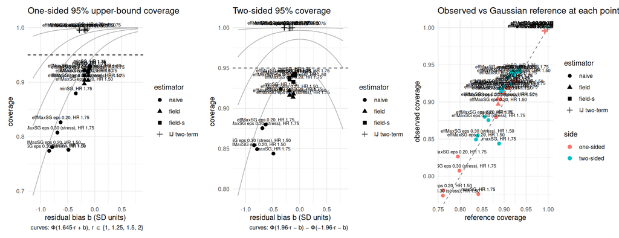

```r
tabC <- COV[COV$block == "Hhat^c (upper)", ]; tabC$estimator <- tabC$construction
fs_plot_bias_coverage(tabC, curves = c(1, 1.25, 1.5, 2), side = "upper")
```

# 3 Finding 1 — Complement upper coverage: field vs field-s (Wilson), per cell

```r
wil <- function(x, n, z = qnorm(.975)) { c <- (x + z^2/(2*n))/(1+z^2/n); h <- z*sqrt(x*(1-x)/n + z^2/(4*n^2))/(1+z^2/n); c(c - h, c + h) }
F1 <- do.call(rbind, lapply(names(B), function(k) { r <- B[[k]]$e1$results; d <- r[r$detected %in% 1L & is.finite(r$betaHhat_Hc) & is.finite(r$fld_Hc_up1s_s), ]
  cf <- mean(d$betaHhat_Hc <= d$fld_Hc_up1s); cs <- mean(d$betaHhat_Hc <= d$fld_Hc_up1s_s); ci <- mean(d$betaHhat_Hc <= exp(log(d$mr_Hc_est) + qnorm(.95) * d$mr_Hc_se_ij))
  wf <- wil(cf, nrow(d)); ws <- wil(cs, nrow(d)); wi <- wil(ci, nrow(d))
  data.frame(cell = labs[[k]], kind = kind[[k]], n = nrow(d), field = cf, field_lo = wf[1], field_hi = wf[2], field_s = cs, field_s_lo = ws[1], field_s_hi = ws[2],
             ij = ci, ij_lo = wi[1], ij_hi = wi[2], field_s_minus_field = cs - cf, share_flipped_to_cover = mean(d$betaHhat_Hc > d$fld_Hc_up1s & d$betaHhat_Hc <= d$fld_Hc_up1s_s),
             share_flipped_to_miss = mean(d$betaHhat_Hc <= d$fld_Hc_up1s & d$betaHhat_Hc > d$fld_Hc_up1s_s), mean_rho_c = mean(d$fld_Hc_scale_ratio), lamSD_over_nSE = sqrt(mean(d$fld_Hc_se^2)) / sqrt(mean(d$nv_Hc_se^2)),
             lamSDs_over_nSE = sqrt(mean(d$fld_Hc_se_s^2)) / sqrt(mean(d$nv_Hc_se^2)), field_s_ge_092 = ws[1] >= 0.92, field_s_point_ge_092 = cs >= 0.92) }))
kbl(F1, digits = 3, booktabs = TRUE, row.names = FALSE, caption = "One-sided 95% upper coverage of beta(Hhat^c): field, field-s, IJ two-term with Wilson limits; the replicates that flip; mean rho^c and the lambda-SD / naive SE ratios (unscaled and studentized). field_s_ge_092: the Wilson lower limit reaches 0.92; field_s_point_ge_092: the point estimate does.") |> kable_styling(font_size = 10)
```

One-sided 95% upper coverage of beta(Hhat^c): field, field-s, IJ two-term with Wilson limits; the replicates that flip; mean rho^c and the lambda-SD / naive SE ratios (unscaled and studentized). field_s_ge_092: the Wilson lower limit reaches 0.92; field_s_point_ge_092: the point estimate does.

| cell | kind | n | field | field_lo | field_hi | field_s | field_s_lo | field_s_hi | ij | ij_lo | ij_hi | field_s_minus_field | share_flipped_to_cover | share_flipped_to_miss | mean_rho_c | lamSD_over_nSE | lamSDs_over_nSE | field_s_ge_092 | field_s_point_ge_092 |
| --- | --- | --- | --- | --- | --- | --- | --- | --- | --- | --- | --- | --- | --- | --- | --- | --- | --- | --- | --- |
| effMaxSG eps 0.20, HR 1.50 | band | 1999 | 0.897 | 0.883 | 0.910 | 0.912 | 0.899 | 0.924 | 0.995 | 0.991 | 0.997 | 0.016 | 0.018 | 0.002 | 1.054 | 0.947 | 0.998 | FALSE | FALSE |
| effMaxSG eps 0.20, HR 1.75 | band | 1999 | 0.912 | 0.899 | 0.924 | 0.919 | 0.907 | 0.931 | 0.995 | 0.991 | 0.998 | 0.007 | 0.010 | 0.003 | 1.058 | 0.946 | 1.001 | FALSE | FALSE |
| effMaxSG eps 0.30 (stress), HR 1.50 | band | 1999 | 0.904 | 0.890 | 0.916 | 0.921 | 0.909 | 0.932 | 0.996 | 0.992 | 0.998 | 0.018 | 0.018 | 0.001 | 1.087 | 0.917 | 0.997 | FALSE | TRUE |
| effMaxSG eps 0.30 (stress), HR 1.75 | band | 1999 | 0.903 | 0.890 | 0.916 | 0.919 | 0.906 | 0.930 | 0.996 | 0.993 | 0.998 | 0.016 | 0.017 | 0.002 | 1.083 | 0.925 | 1.002 | FALSE | FALSE |
| maxSG, HR 1.75 | end | 1999 | 0.925 | 0.913 | 0.936 | 0.926 | 0.914 | 0.937 | 0.995 | 0.991 | 0.997 | 0.002 | 0.015 | 0.013 | 0.997 | 0.988 | 1.014 | FALSE | TRUE |
| minSG, HR 1.75 | end | 1999 | 0.929 | 0.917 | 0.940 | 0.929 | 0.917 | 0.939 | 0.997 | 0.994 | 0.999 | -0.001 | 0.002 | 0.002 | 1.006 | 0.994 | 1.000 | FALSE | TRUE |

# 4 Finding 2 — The shape test: complement upper coverage by |Hhat|/|H| tertile and by p-hat tertile

```r
tert <- function(v) { br <- quantile(v, c(0, 1/3, 2/3, 1), names = FALSE); cut(v, breaks = unique(br), include.lowest = TRUE, labels = FALSE) }
F2 <- do.call(rbind, lapply(names(B), function(k) { r <- B[[k]]$e1$results; d <- r[r$detected %in% 1L & is.finite(r$betaHhat_Hc) & is.finite(r$fld_Hc_up1s_s), ]
  do.call(rbind, lapply(c("|Hhat|/|H|", "p-hat"), function(what) { v <- if (what == "p-hat") d$p_hat_H else d$n_harm / d$n_true; g <- tert(v)
    do.call(rbind, lapply(sort(unique(g)), function(t) { dk <- d[g == t, ]; cf <- mean(dk$betaHhat_Hc <= dk$fld_Hc_up1s); cs <- mean(dk$betaHhat_Hc <= dk$fld_Hc_up1s_s)
      wf <- wil(cf, nrow(dk)); ws <- wil(cs, nrow(dk))
      data.frame(cell = labs[[k]], stratum = sprintf("%s T%d [%.2f, %.2f]", what, t, min(v[g == t]), max(v[g == t])), n = nrow(dk), mean_rho_c = mean(dk$fld_Hc_scale_ratio),
                 fld_over_nv = mean(dk$fld_Hc_se / dk$nv_Hc_se), flds_over_nv = mean(dk$fld_Hc_se_s / dk$nv_Hc_se),
                 field = cf, field_lo = wf[1], field_hi = wf[2], field_s = cs, field_s_lo = ws[1], field_s_hi = ws[2]) })) })) }))
kbl(F2, digits = 3, booktabs = TRUE, row.names = FALSE, caption = "Within each cell, by |Hhat|/|H| tertile and by p-hat(Hhat) tertile: mean rho^c, the per-replicate SE ratios, and the field / field-s upper coverage of beta(Hhat^c) with Wilson limits.") |> kable_styling(font_size = 9)
```

Within each cell, by |Hhat|/|H| tertile and by p-hat(Hhat) tertile: mean rho^c, the per-replicate SE ratios, and the field / field-s upper coverage of beta(Hhat^c) with Wilson limits.

| cell | stratum | n | mean_rho_c | fld_over_nv | flds_over_nv | field | field_lo | field_hi | field_s | field_s_lo | field_s_hi |
| --- | --- | --- | --- | --- | --- | --- | --- | --- | --- | --- | --- |
| effMaxSG eps 0.20, HR 1.50 | \|Hhat\|/\|H\| T1 [0.37, 0.69] | 667 | 1.001 | 1.002 | 0.999 | 0.918 | 0.894 | 0.936 | 0.916 | 0.893 | 0.935 |
| effMaxSG eps 0.20, HR 1.50 | \|Hhat\|/\|H\| T2 [0.69, 0.95] | 666 | 1.041 | 0.964 | 1.000 | 0.892 | 0.866 | 0.913 | 0.904 | 0.879 | 0.924 |
| effMaxSG eps 0.20, HR 1.50 | \|Hhat\|/\|H\| T3 [0.95, 2.09] | 666 | 1.120 | 0.892 | 0.994 | 0.881 | 0.855 | 0.904 | 0.917 | 0.894 | 0.936 |
| effMaxSG eps 0.20, HR 1.50 | p-hat T1 [0.00, 0.04] | 669 | 1.103 | 0.908 | 0.994 | 0.912 | 0.888 | 0.931 | 0.936 | 0.915 | 0.952 |
| effMaxSG eps 0.20, HR 1.50 | p-hat T2 [0.04, 0.11] | 664 | 1.047 | 0.956 | 0.996 | 0.907 | 0.882 | 0.926 | 0.917 | 0.894 | 0.936 |
| effMaxSG eps 0.20, HR 1.50 | p-hat T3 [0.11, 0.82] | 666 | 1.012 | 0.994 | 1.003 | 0.872 | 0.845 | 0.896 | 0.884 | 0.858 | 0.906 |
| effMaxSG eps 0.20, HR 1.75 | \|Hhat\|/\|H\| T1 [0.35, 0.71] | 667 | 1.002 | 1.002 | 1.002 | 0.922 | 0.899 | 0.940 | 0.915 | 0.891 | 0.933 |
| effMaxSG eps 0.20, HR 1.75 | \|Hhat\|/\|H\| T2 [0.71, 0.97] | 666 | 1.047 | 0.960 | 1.003 | 0.905 | 0.881 | 0.925 | 0.908 | 0.884 | 0.928 |
| effMaxSG eps 0.20, HR 1.75 | \|Hhat\|/\|H\| T3 [0.97, 1.93] | 666 | 1.125 | 0.890 | 0.997 | 0.910 | 0.886 | 0.929 | 0.935 | 0.914 | 0.952 |
| effMaxSG eps 0.20, HR 1.75 | p-hat T1 [0.00, 0.05] | 667 | 1.107 | 0.906 | 0.997 | 0.943 | 0.923 | 0.958 | 0.954 | 0.935 | 0.967 |
| effMaxSG eps 0.20, HR 1.75 | p-hat T2 [0.05, 0.13] | 666 | 1.049 | 0.955 | 0.998 | 0.916 | 0.892 | 0.935 | 0.928 | 0.906 | 0.945 |
| effMaxSG eps 0.20, HR 1.75 | p-hat T3 [0.13, 0.93] | 666 | 1.017 | 0.992 | 1.007 | 0.878 | 0.851 | 0.901 | 0.877 | 0.850 | 0.900 |
| effMaxSG eps 0.30 (stress), HR 1.50 | \|Hhat\|/\|H\| T1 [0.37, 0.97] | 667 | 1.017 | 0.987 | 0.999 | 0.909 | 0.884 | 0.928 | 0.910 | 0.886 | 0.929 |
| effMaxSG eps 0.30 (stress), HR 1.50 | \|Hhat\|/\|H\| T2 [0.97, 1.24] | 666 | 1.082 | 0.928 | 1.000 | 0.916 | 0.892 | 0.935 | 0.931 | 0.909 | 0.948 |
| effMaxSG eps 0.30 (stress), HR 1.50 | \|Hhat\|/\|H\| T3 [1.24, 2.41] | 666 | 1.162 | 0.864 | 0.993 | 0.887 | 0.861 | 0.909 | 0.923 | 0.901 | 0.941 |
| effMaxSG eps 0.30 (stress), HR 1.50 | p-hat T1 [0.00, 0.03] | 671 | 1.151 | 0.874 | 0.993 | 0.920 | 0.896 | 0.938 | 0.945 | 0.925 | 0.960 |
| effMaxSG eps 0.30 (stress), HR 1.50 | p-hat T2 [0.03, 0.07] | 662 | 1.073 | 0.935 | 0.996 | 0.917 | 0.893 | 0.936 | 0.932 | 0.910 | 0.949 |
| effMaxSG eps 0.30 (stress), HR 1.50 | p-hat T3 [0.07, 0.69] | 666 | 1.037 | 0.971 | 1.003 | 0.875 | 0.848 | 0.898 | 0.887 | 0.861 | 0.909 |
| effMaxSG eps 0.30 (stress), HR 1.75 | \|Hhat\|/\|H\| T1 [0.39, 0.98] | 667 | 1.020 | 0.987 | 1.003 | 0.913 | 0.889 | 0.932 | 0.913 | 0.889 | 0.932 |
| effMaxSG eps 0.30 (stress), HR 1.75 | \|Hhat\|/\|H\| T2 [0.98, 1.22] | 666 | 1.080 | 0.932 | 1.003 | 0.919 | 0.896 | 0.937 | 0.929 | 0.907 | 0.947 |
| effMaxSG eps 0.30 (stress), HR 1.75 | \|Hhat\|/\|H\| T3 [1.22, 2.35] | 666 | 1.150 | 0.876 | 0.999 | 0.878 | 0.851 | 0.901 | 0.914 | 0.891 | 0.933 |
| effMaxSG eps 0.30 (stress), HR 1.75 | p-hat T1 [0.00, 0.03] | 667 | 1.143 | 0.880 | 0.996 | 0.918 | 0.894 | 0.936 | 0.936 | 0.914 | 0.952 |
| effMaxSG eps 0.30 (stress), HR 1.75 | p-hat T2 [0.04, 0.08] | 666 | 1.069 | 0.940 | 1.000 | 0.920 | 0.897 | 0.939 | 0.937 | 0.916 | 0.953 |
| effMaxSG eps 0.30 (stress), HR 1.75 | p-hat T3 [0.08, 0.87] | 666 | 1.037 | 0.975 | 1.009 | 0.872 | 0.845 | 0.896 | 0.884 | 0.858 | 0.906 |
| maxSG, HR 1.75 | \|Hhat\|/\|H\| T1 [0.45, 2.52] | 667 | 0.828 | 1.262 | 0.971 | 0.916 | 0.893 | 0.935 | 0.888 | 0.861 | 0.909 |
| maxSG, HR 1.75 | \|Hhat\|/\|H\| T2 [2.52, 2.89] | 678 | 1.033 | 1.029 | 1.010 | 0.925 | 0.902 | 0.942 | 0.937 | 0.916 | 0.953 |
| maxSG, HR 1.75 | \|Hhat\|/\|H\| T3 [2.89, 3.64] | 654 | 1.131 | 0.924 | 1.021 | 0.934 | 0.913 | 0.951 | 0.956 | 0.937 | 0.969 |
| maxSG, HR 1.75 | p-hat T1 [0.01, 0.12] | 667 | 0.824 | 1.271 | 0.973 | 0.948 | 0.928 | 0.962 | 0.922 | 0.899 | 0.940 |
| maxSG, HR 1.75 | p-hat T2 [0.12, 0.64] | 666 | 1.086 | 0.993 | 1.003 | 0.874 | 0.846 | 0.897 | 0.893 | 0.868 | 0.915 |
| maxSG, HR 1.75 | p-hat T3 [0.64, 1.00] | 666 | 1.081 | 0.953 | 1.026 | 0.953 | 0.935 | 0.967 | 0.964 | 0.947 | 0.976 |
| minSG, HR 1.75 | \|Hhat\|/\|H\| T1 [0.33, 0.39] | 679 | 1.004 | 0.995 | 0.999 | 0.946 | 0.926 | 0.960 | 0.944 | 0.924 | 0.959 |
| minSG, HR 1.75 | \|Hhat\|/\|H\| T2 [0.39, 0.42] | 654 | 1.007 | 0.994 | 1.000 | 0.927 | 0.904 | 0.944 | 0.931 | 0.909 | 0.948 |
| minSG, HR 1.75 | \|Hhat\|/\|H\| T3 [0.42, 1.04] | 666 | 1.007 | 0.995 | 1.001 | 0.916 | 0.892 | 0.935 | 0.911 | 0.887 | 0.931 |
| minSG, HR 1.75 | p-hat T1 [0.00, 0.01] | 669 | 1.005 | 0.998 | 1.002 | 0.955 | 0.937 | 0.968 | 0.957 | 0.938 | 0.970 |
| minSG, HR 1.75 | p-hat T2 [0.01, 0.08] | 664 | 1.006 | 0.997 | 1.002 | 0.935 | 0.914 | 0.952 | 0.932 | 0.911 | 0.949 |
| minSG, HR 1.75 | p-hat T3 [0.08, 0.87] | 666 | 1.007 | 0.989 | 0.996 | 0.898 | 0.873 | 0.919 | 0.898 | 0.873 | 0.919 |

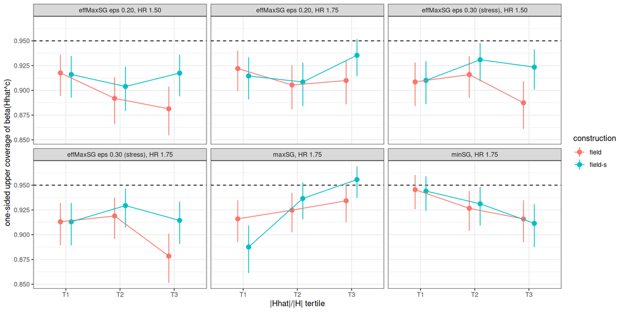

```r
P2 <- F2[grepl("^\\|Hhat", F2$stratum), ]; P2$tertile <- sub(" \\[.*", "", sub("^\\|Hhat\\|/\\|H\\| ", "", P2$stratum))
P2l <- rbind(data.frame(cell = P2$cell, tertile = P2$tertile, construction = "field", cov = P2$field, lo = P2$field_lo, hi = P2$field_hi),
             data.frame(cell = P2$cell, tertile = P2$tertile, construction = "field-s", cov = P2$field_s, lo = P2$field_s_lo, hi = P2$field_s_hi))
ggplot(P2l, aes(x = tertile, y = cov, colour = construction, group = construction)) + geom_hline(yintercept = 0.95, linetype = 2) +
  geom_pointrange(aes(ymin = lo, ymax = hi), position = position_dodge(width = 0.4)) + geom_line(position = position_dodge(width = 0.4)) +
  facet_wrap(~ cell, ncol = 3) + labs(x = "|Hhat|/|H| tertile", y = "one-sided upper coverage of beta(Hhat^c)") + theme_bw(base_size = 11)
```

# 5 Finding 3 — The no-regression ends (maxSG, minSG)

```r
kbl(F1[F1$kind == "end", c("cell", "n", "field", "field_lo", "field_hi", "field_s", "field_s_lo", "field_s_hi", "field_s_minus_field", "share_flipped_to_cover", "share_flipped_to_miss", "mean_rho_c", "lamSD_over_nSE", "lamSDs_over_nSE")],
    digits = 3, booktabs = TRUE, row.names = FALSE, caption = "The ends: field-s against field where the pick is concentrated (mechanism prediction: rho^c ~ 1, field-s ~ field).") |> kable_styling(font_size = 10)
```

The ends: field-s against field where the pick is concentrated (mechanism prediction: rho^c ~ 1, field-s ~ field).

| cell | n | field | field_lo | field_hi | field_s | field_s_lo | field_s_hi | field_s_minus_field | share_flipped_to_cover | share_flipped_to_miss | mean_rho_c | lamSD_over_nSE | lamSDs_over_nSE |
| --- | --- | --- | --- | --- | --- | --- | --- | --- | --- | --- | --- | --- | --- |
| maxSG, HR 1.75 | 1999 | 0.925 | 0.913 | 0.936 | 0.926 | 0.914 | 0.937 | 0.002 | 0.015 | 0.013 | 0.997 | 0.988 | 1.014 |
| minSG, HR 1.75 | 1999 | 0.929 | 0.917 | 0.940 | 0.929 | 0.917 | 0.939 | -0.001 | 0.002 | 0.002 | 1.006 | 0.994 | 1.000 |

# 6 Finding 4 — Bound locations and the joint pair

```r
LOC <- do.call(rbind, lapply(names(B), function(k) { d <- B[[k]]$e1$results; d <- d[d$detected %in% 1L, ]
  rows <- list(naive = list(lo = exp(log(d$nv_H_est) - qnorm(.95) * d$nv_H_se), up = exp(log(d$nv_Hc_est) + qnorm(.95) * d$nv_Hc_se)),
               `IJ two-term` = list(lo = exp(log(d$mr_H_est) - qnorm(.95) * d$mr_H_se_ij), up = exp(log(d$mr_Hc_est) + qnorm(.95) * d$mr_Hc_se_ij)),
               field = list(lo = d$fld_H_lo1s, up = d$fld_Hc_up1s), `field-s` = list(lo = d$fld_H_lo1s, up = d$fld_Hc_up1s_s))
  do.call(rbind, lapply(names(rows), function(nm) { p <- rows[[nm]]; ok <- is.finite(p$lo) & is.finite(p$up)
    data.frame(cell = labs[[k]], construction = nm, mean_betaH = mean(d$betaHhat_H), mean_betaHc = mean(d$betaHhat_Hc),
               H_lower_mean = mean(p$lo[ok]), share_ge_085 = mean(p$lo[ok] >= 0.85), share_ge_095 = mean(p$lo[ok] >= 0.95),
               Hc_upper_mean = mean(p$up[ok]), share_lt_085 = mean(p$up[ok] < 0.85), share_lt_080 = mean(p$up[ok] < 0.80),
               margin_Hc = mean(log(p$up[ok]) - log(d$mr_Hc_est[ok])), stringsAsFactors = FALSE) })) }))
kbl(LOC, digits = 3, booktabs = TRUE, row.names = FALSE, caption = "Bound locations (HR scale): the harm lower bound against 0.85 / 0.95 (field-s = field there), the complement upper bound against 0.85 / 0.80; margin_Hc = mean log(upper) - log(mr_Hc_est).") |> kable_styling(font_size = 10)
```

Bound locations (HR scale): the harm lower bound against 0.85 / 0.95 (field-s = field there), the complement upper bound against 0.85 / 0.80; margin_Hc = mean log(upper) - log(mr_Hc_est).

| cell | construction | mean_betaH | mean_betaHc | H_lower_mean | share_ge_085 | share_ge_095 | Hc_upper_mean | share_lt_085 | share_lt_080 | margin_Hc |
| --- | --- | --- | --- | --- | --- | --- | --- | --- | --- | --- |
| effMaxSG eps 0.20, HR 1.50 | naive | 1.256 | 0.808 | 1.289 | 0.985 | 0.927 | 0.909 | 0.349 | 0.216 | 0.156 |
| effMaxSG eps 0.20, HR 1.50 | IJ two-term | 1.256 | 0.808 | 0.705 | 0.181 | 0.095 | 1.188 | 0.020 | 0.007 | 0.422 |
| effMaxSG eps 0.20, HR 1.50 | field | 1.256 | 0.808 | 0.693 | 0.196 | 0.115 | 0.987 | 0.192 | 0.109 | 0.237 |
| effMaxSG eps 0.20, HR 1.50 | field-s | 1.256 | 0.808 | 0.693 | 0.196 | 0.115 | 0.997 | 0.164 | 0.092 | 0.247 |
| effMaxSG eps 0.20, HR 1.75 | naive | 1.515 | 0.808 | 1.473 | 0.998 | 0.986 | 0.929 | 0.299 | 0.181 | 0.163 |
| effMaxSG eps 0.20, HR 1.75 | IJ two-term | 1.515 | 0.808 | 0.827 | 0.383 | 0.243 | 1.207 | 0.019 | 0.006 | 0.425 |
| effMaxSG eps 0.20, HR 1.75 | field | 1.515 | 0.808 | 0.821 | 0.371 | 0.260 | 0.999 | 0.178 | 0.104 | 0.234 |
| effMaxSG eps 0.20, HR 1.75 | field-s | 1.515 | 0.808 | 0.821 | 0.371 | 0.260 | 1.010 | 0.156 | 0.084 | 0.246 |
| effMaxSG eps 0.30 (stress), HR 1.50 | naive | 1.228 | 0.779 | 1.173 | 0.950 | 0.835 | 0.880 | 0.428 | 0.284 | 0.162 |
| effMaxSG eps 0.30 (stress), HR 1.50 | IJ two-term | 1.228 | 0.779 | 0.672 | 0.127 | 0.056 | 1.159 | 0.028 | 0.011 | 0.438 |
| effMaxSG eps 0.30 (stress), HR 1.50 | field | 1.228 | 0.779 | 0.678 | 0.165 | 0.092 | 0.961 | 0.252 | 0.160 | 0.248 |
| effMaxSG eps 0.30 (stress), HR 1.50 | field-s | 1.228 | 0.779 | 0.678 | 0.165 | 0.092 | 0.977 | 0.214 | 0.129 | 0.266 |
| effMaxSG eps 0.30 (stress), HR 1.75 | naive | 1.454 | 0.774 | 1.337 | 0.990 | 0.950 | 0.894 | 0.402 | 0.261 | 0.170 |
| effMaxSG eps 0.30 (stress), HR 1.75 | IJ two-term | 1.454 | 0.774 | 0.786 | 0.311 | 0.181 | 1.171 | 0.028 | 0.008 | 0.440 |
| effMaxSG eps 0.30 (stress), HR 1.75 | field | 1.454 | 0.774 | 0.805 | 0.340 | 0.224 | 0.965 | 0.249 | 0.151 | 0.245 |
| effMaxSG eps 0.30 (stress), HR 1.75 | field-s | 1.454 | 0.774 | 0.805 | 0.340 | 0.224 | 0.981 | 0.210 | 0.128 | 0.262 |
| maxSG, HR 1.75 | naive | 1.014 | 0.758 | 0.852 | 0.351 | 0.082 | 1.258 | 0.330 | 0.257 | 0.457 |
| maxSG, HR 1.75 | IJ two-term | 1.014 | 0.758 | 0.706 | 0.015 | 0.001 | 2.321 | 0.019 | 0.009 | 1.022 |
| maxSG, HR 1.75 | field | 1.014 | 0.758 | 0.828 | 0.271 | 0.079 | 1.389 | 0.143 | 0.102 | 0.584 |
| maxSG, HR 1.75 | field-s | 1.014 | 0.758 | 0.828 | 0.271 | 0.079 | 1.451 | 0.144 | 0.103 | 0.611 |
| minSG, HR 1.75 | naive | 1.304 | 0.915 | 1.062 | 0.846 | 0.584 | 1.088 | 0.039 | 0.015 | 0.184 |
| minSG, HR 1.75 | IJ two-term | 1.304 | 0.915 | 0.738 | 0.209 | 0.118 | 1.368 | 0.001 | 0.000 | 0.413 |
| minSG, HR 1.75 | field | 1.304 | 0.915 | 0.790 | 0.318 | 0.206 | 1.125 | 0.025 | 0.010 | 0.218 |
| minSG, HR 1.75 | field-s | 1.304 | 0.915 | 0.790 | 0.318 | 0.206 | 1.127 | 0.023 | 0.010 | 0.219 |

```r
JNT <- do.call(rbind, lapply(names(B), function(k) { r <- B[[k]]$e1$results
  d <- r[r$detected %in% 1L & is.finite(r$betaHhat_H) & is.finite(r$betaHhat_Hc) & is.finite(r$fld_joint_gamma) & is.finite(r$fld_joint_s_gamma), ]
  pairs <- list(`separate 95% (field)` = list(lo = d$fld_H_lo1s, up = d$fld_Hc_up1s, g = NA, cr = NA), `separate 95% (field-s)` = list(lo = d$fld_H_lo1s, up = d$fld_Hc_up1s_s, g = NA, cr = NA),
                `Bonferroni (joint)` = list(lo = d$fld_joint_bonf_loH, up = d$fld_joint_bonf_upHc, g = 0.025, cr = d$fld_joint_corr), `Bonferroni (joint_s)` = list(lo = d$fld_joint_s_bonf_loH, up = d$fld_joint_s_bonf_upHc, g = 0.025, cr = d$fld_joint_s_corr),
                `calibrated (joint)` = list(lo = d$fld_joint_loH, up = d$fld_joint_upHc, g = d$fld_joint_gamma, cr = d$fld_joint_corr), `calibrated (joint_s)` = list(lo = d$fld_joint_s_loH, up = d$fld_joint_s_upHc, g = d$fld_joint_s_gamma, cr = d$fld_joint_s_corr))
  do.call(rbind, lapply(names(pairs), function(nm) { p <- pairs[[nm]]; cH <- d$betaHhat_H >= p$lo; cC <- d$betaHhat_Hc <= p$up; jc <- mean(cH & cC); w <- wil(jc, nrow(d))
    data.frame(cell = labs[[k]], pair = nm, n = nrow(d), joint_cov = jc, wilson_lo = w[1], wilson_hi = w[2], cov_H = mean(cH), cov_Hc = mean(cC),
               margin_H = mean(log(d$mr_H_est) - log(p$lo)), margin_Hc = mean(log(p$up) - log(d$mr_Hc_est)), mean_gamma = mean(p$g), mean_corr = mean(p$cr), stringsAsFactors = FALSE) })) }))
kbl(JNT, digits = 3, booktabs = TRUE, row.names = FALSE, caption = "Joint coverage of (beta(Hhat) >= lower_H, beta(Hhat^c) <= upper_Hc), Wilson limits: the separate 95% bounds, the Bonferroni pair and the calibrated pair, from the unscaled joint and from joint_s.") |> kable_styling(font_size = 9)
```

Joint coverage of (beta(Hhat) >= lower_H, beta(Hhat^c) <= upper_Hc), Wilson limits: the separate 95% bounds, the Bonferroni pair and the calibrated pair, from the unscaled joint and from joint_s.

| cell | pair | n | joint_cov | wilson_lo | wilson_hi | cov_H | cov_Hc | margin_H | margin_Hc | mean_gamma | mean_corr |
| --- | --- | --- | --- | --- | --- | --- | --- | --- | --- | --- | --- |
| effMaxSG eps 0.20, HR 1.50 | separate 95% (field) | 1999 | 0.872 | 0.857 | 0.886 | 0.974 | 0.897 | 0.624 | 0.237 | NA | NA |
| effMaxSG eps 0.20, HR 1.50 | separate 95% (field-s) | 1999 | 0.888 | 0.873 | 0.901 | 0.974 | 0.912 | 0.624 | 0.247 | NA | NA |
| effMaxSG eps 0.20, HR 1.50 | Bonferroni (joint) | 1999 | 0.932 | 0.920 | 0.942 | 0.989 | 0.942 | 0.762 | 0.280 | 0.025 | 0.041 |
| effMaxSG eps 0.20, HR 1.50 | Bonferroni (joint_s) | 1999 | 0.942 | 0.931 | 0.951 | 0.989 | 0.952 | 0.762 | 0.292 | 0.025 | 0.031 |
| effMaxSG eps 0.20, HR 1.50 | calibrated (joint) | 1999 | 0.932 | 0.920 | 0.942 | 0.989 | 0.942 | 0.761 | 0.279 | 0.025 | 0.041 |
| effMaxSG eps 0.20, HR 1.50 | calibrated (joint_s) | 1999 | 0.942 | 0.931 | 0.951 | 0.989 | 0.952 | 0.761 | 0.291 | 0.025 | 0.031 |
| effMaxSG eps 0.20, HR 1.75 | separate 95% (field) | 1999 | 0.885 | 0.870 | 0.898 | 0.970 | 0.912 | 0.611 | 0.234 | NA | NA |
| effMaxSG eps 0.20, HR 1.75 | separate 95% (field-s) | 1999 | 0.892 | 0.878 | 0.905 | 0.970 | 0.919 | 0.611 | 0.246 | NA | NA |
| effMaxSG eps 0.20, HR 1.75 | Bonferroni (joint) | 1999 | 0.933 | 0.922 | 0.944 | 0.986 | 0.947 | 0.747 | 0.276 | 0.025 | 0.019 |
| effMaxSG eps 0.20, HR 1.75 | Bonferroni (joint_s) | 1999 | 0.939 | 0.928 | 0.949 | 0.986 | 0.953 | 0.747 | 0.290 | 0.025 | 0.009 |
| effMaxSG eps 0.20, HR 1.75 | calibrated (joint) | 1999 | 0.933 | 0.921 | 0.943 | 0.986 | 0.946 | 0.746 | 0.276 | 0.025 | 0.019 |
| effMaxSG eps 0.20, HR 1.75 | calibrated (joint_s) | 1999 | 0.939 | 0.928 | 0.949 | 0.986 | 0.953 | 0.746 | 0.290 | 0.025 | 0.009 |
| effMaxSG eps 0.30 (stress), HR 1.50 | separate 95% (field) | 1999 | 0.886 | 0.872 | 0.900 | 0.980 | 0.904 | 0.555 | 0.248 | NA | NA |
| effMaxSG eps 0.30 (stress), HR 1.50 | separate 95% (field-s) | 1999 | 0.904 | 0.890 | 0.916 | 0.980 | 0.921 | 0.555 | 0.266 | NA | NA |
| effMaxSG eps 0.30 (stress), HR 1.50 | Bonferroni (joint) | 1999 | 0.935 | 0.923 | 0.945 | 0.993 | 0.941 | 0.691 | 0.294 | 0.025 | 0.039 |
| effMaxSG eps 0.30 (stress), HR 1.50 | Bonferroni (joint_s) | 1999 | 0.949 | 0.939 | 0.958 | 0.993 | 0.955 | 0.691 | 0.314 | 0.025 | 0.025 |
| effMaxSG eps 0.30 (stress), HR 1.50 | calibrated (joint) | 1999 | 0.935 | 0.923 | 0.945 | 0.993 | 0.941 | 0.690 | 0.294 | 0.025 | 0.039 |
| effMaxSG eps 0.30 (stress), HR 1.50 | calibrated (joint_s) | 1999 | 0.949 | 0.939 | 0.958 | 0.993 | 0.955 | 0.690 | 0.314 | 0.025 | 0.025 |
| effMaxSG eps 0.30 (stress), HR 1.75 | separate 95% (field) | 1999 | 0.881 | 0.867 | 0.895 | 0.976 | 0.903 | 0.542 | 0.245 | NA | NA |
| effMaxSG eps 0.30 (stress), HR 1.75 | separate 95% (field-s) | 1999 | 0.897 | 0.883 | 0.910 | 0.976 | 0.919 | 0.542 | 0.262 | NA | NA |
| effMaxSG eps 0.30 (stress), HR 1.75 | Bonferroni (joint) | 1999 | 0.935 | 0.923 | 0.945 | 0.992 | 0.943 | 0.676 | 0.290 | 0.025 | 0.012 |
| effMaxSG eps 0.30 (stress), HR 1.75 | Bonferroni (joint_s) | 1999 | 0.952 | 0.942 | 0.961 | 0.992 | 0.960 | 0.676 | 0.310 | 0.025 | 0.000 |
| effMaxSG eps 0.30 (stress), HR 1.75 | calibrated (joint) | 1999 | 0.935 | 0.923 | 0.945 | 0.992 | 0.943 | 0.675 | 0.290 | 0.025 | 0.012 |
| effMaxSG eps 0.30 (stress), HR 1.75 | calibrated (joint_s) | 1999 | 0.951 | 0.941 | 0.960 | 0.992 | 0.959 | 0.675 | 0.310 | 0.025 | 0.000 |
| maxSG, HR 1.75 | separate 95% (field) | 1999 | 0.876 | 0.861 | 0.890 | 0.947 | 0.925 | 0.204 | 0.584 | NA | NA |
| maxSG, HR 1.75 | separate 95% (field-s) | 1999 | 0.878 | 0.863 | 0.892 | 0.947 | 0.926 | 0.204 | 0.611 | NA | NA |
| maxSG, HR 1.75 | Bonferroni (joint) | 1999 | 0.942 | 0.931 | 0.952 | 0.975 | 0.966 | 0.243 | 0.710 | 0.025 | 0.035 |
| maxSG, HR 1.75 | Bonferroni (joint_s) | 1999 | 0.939 | 0.928 | 0.949 | 0.975 | 0.963 | 0.243 | 0.722 | 0.025 | 0.073 |
| maxSG, HR 1.75 | calibrated (joint) | 1999 | 0.941 | 0.930 | 0.951 | 0.975 | 0.965 | 0.241 | 0.706 | 0.026 | 0.035 |
| maxSG, HR 1.75 | calibrated (joint_s) | 1999 | 0.939 | 0.928 | 0.949 | 0.975 | 0.963 | 0.242 | 0.721 | 0.025 | 0.073 |
| minSG, HR 1.75 | separate 95% (field) | 1999 | 0.869 | 0.854 | 0.883 | 0.936 | 0.929 | 0.589 | 0.218 | NA | NA |
| minSG, HR 1.75 | separate 95% (field-s) | 1999 | 0.869 | 0.853 | 0.883 | 0.936 | 0.929 | 0.589 | 0.219 | NA | NA |
| minSG, HR 1.75 | Bonferroni (joint) | 1999 | 0.930 | 0.918 | 0.940 | 0.965 | 0.963 | 0.702 | 0.258 | 0.025 | 0.020 |
| minSG, HR 1.75 | Bonferroni (joint_s) | 1999 | 0.930 | 0.918 | 0.941 | 0.965 | 0.963 | 0.702 | 0.259 | 0.025 | 0.019 |
| minSG, HR 1.75 | calibrated (joint) | 1999 | 0.929 | 0.917 | 0.940 | 0.964 | 0.963 | 0.701 | 0.258 | 0.025 | 0.020 |
| minSG, HR 1.75 | calibrated (joint_s) | 1999 | 0.930 | 0.918 | 0.940 | 0.964 | 0.963 | 0.701 | 0.259 | 0.025 | 0.019 |

# 7 Finding 5 — R1 vs the global rescale: `se_field_s / (rho^c x se_field)` per cell (informational)

```r
F5 <- do.call(rbind, lapply(names(B), function(k) { r <- B[[k]]$e1$results; d <- r[r$detected %in% 1L & is.finite(r$fld_Hc_se_s) & is.finite(r$fld_Hc_scale_ratio), ]
  v <- d$fld_Hc_se_s / (d$fld_Hc_scale_ratio * d$fld_Hc_se); q <- quantile(v, c(.01, .10, .50, .90, .99))
  data.frame(cell = labs[[k]], n = nrow(d), mean = mean(v), sd = sd(v), q01 = q[1], q10 = q[2], q50 = q[3], q90 = q[4], q99 = q[5], min = min(v), max = max(v),
             mean_scale_cv = mean(d$fld_Hc_scale_cv), q90_scale_cv = quantile(d$fld_Hc_scale_cv, .9), mean_rho_c = mean(d$fld_Hc_scale_ratio), share_rho_gt_1 = mean(d$fld_Hc_scale_ratio > 1),
             corr_flds_nv = cor(d$fld_Hc_se_s, d$nv_Hc_se), corr_fld_nv = cor(d$fld_Hc_se, d$nv_Hc_se)) }))
kbl(F5, digits = 4, booktabs = TRUE, row.names = FALSE, caption = "The per-draw (R1) studentized SD against the global rescale rho^c x lambda-SD^c, per cell; the winner-scale CV; rho^c; and the per-replicate correlation of each field SD with the naive SE.") |> kable_styling(font_size = 9)
```

The per-draw (R1) studentized SD against the global rescale rho^c x lambda-SD^c, per cell; the winner-scale CV; rho^c; and the per-replicate correlation of each field SD with the naive SE.

| cell | n | mean | sd | q01 | q10 | q50 | q90 | q99 | min | max | mean_scale_cv | q90_scale_cv | mean_rho_c | share_rho_gt_1 | corr_flds_nv | corr_fld_nv |
| --- | --- | --- | --- | --- | --- | --- | --- | --- | --- | --- | --- | --- | --- | --- | --- | --- |
| effMaxSG eps 0.20, HR 1.50 | 1999 | 0.9979 | 0.0036 | 0.9874 | 0.9933 | 0.9980 | 1.0021 | 1.0061 | 0.9831 | 1.0128 | 0.0521 | 0.0690 | 1.0539 | 0.8069 | 0.9406 | 0.3426 |
| effMaxSG eps 0.20, HR 1.75 | 1999 | 0.9987 | 0.0035 | 0.9896 | 0.9943 | 0.9989 | 1.0029 | 1.0064 | 0.9833 | 1.0105 | 0.0538 | 0.0714 | 1.0578 | 0.8269 | 0.9417 | 0.3618 |
| effMaxSG eps 0.30 (stress), HR 1.50 | 1999 | 0.9960 | 0.0057 | 0.9784 | 0.9888 | 0.9967 | 1.0022 | 1.0068 | 0.9626 | 1.0150 | 0.0714 | 0.0939 | 1.0871 | 0.8654 | 0.9621 | 0.4181 |
| effMaxSG eps 0.30 (stress), HR 1.75 | 1999 | 0.9975 | 0.0050 | 0.9821 | 0.9910 | 0.9980 | 1.0031 | 1.0075 | 0.9700 | 1.0135 | 0.0701 | 0.0922 | 1.0833 | 0.8739 | 0.9580 | 0.4138 |
| maxSG, HR 1.75 | 1999 | 0.9688 | 0.0319 | 0.8816 | 0.9252 | 0.9723 | 1.0055 | 1.0178 | 0.8125 | 1.0308 | 0.2596 | 0.3755 | 0.9968 | 0.5423 | 0.9963 | 0.8827 |
| minSG, HR 1.75 | 1999 | 0.9999 | 0.0009 | 0.9974 | 0.9988 | 1.0000 | 1.0009 | 1.0020 | 0.9945 | 1.0040 | 0.0149 | 0.0221 | 1.0059 | 0.6508 | 0.7413 | 0.5110 |

# 8 Numbers for the record

**Finding 1 (complement upper coverage; field / field-s / IJ, Wilson):**

- effMaxSG eps 0.20, HR 1.50 (n 1999): field 0.897 [0.883, 0.910]; field-s 0.912 [0.899, 0.924]; IJ 0.995 [0.991, 0.997]; flips to cover 0.018, to miss 0.002; mean rho^c 1.054; lambda-SD/nSE 0.947 -> 0.998
- effMaxSG eps 0.20, HR 1.75 (n 1999): field 0.912 [0.899, 0.924]; field-s 0.919 [0.907, 0.931]; IJ 0.995 [0.991, 0.998]; flips to cover 0.010, to miss 0.003; mean rho^c 1.058; lambda-SD/nSE 0.946 -> 1.001
- effMaxSG eps 0.30 (stress), HR 1.50 (n 1999): field 0.904 [0.890, 0.916]; field-s 0.921 [0.909, 0.932]; IJ 0.996 [0.992, 0.998]; flips to cover 0.018, to miss 0.001; mean rho^c 1.087; lambda-SD/nSE 0.917 -> 0.997
- effMaxSG eps 0.30 (stress), HR 1.75 (n 1999): field 0.903 [0.890, 0.916]; field-s 0.919 [0.906, 0.930]; IJ 0.996 [0.993, 0.998]; flips to cover 0.017, to miss 0.002; mean rho^c 1.083; lambda-SD/nSE 0.925 -> 1.002
- maxSG, HR 1.75 (n 1999): field 0.925 [0.913, 0.936]; field-s 0.926 [0.914, 0.937]; IJ 0.995 [0.991, 0.997]; flips to cover 0.015, to miss 0.013; mean rho^c 0.997; lambda-SD/nSE 0.988 -> 1.014
- minSG, HR 1.75 (n 1999): field 0.929 [0.917, 0.940]; field-s 0.929 [0.917, 0.939]; IJ 0.997 [0.994, 0.999]; flips to cover 0.002, to miss 0.002; mean rho^c 1.006; lambda-SD/nSE 0.994 -> 1.000

**Finding 2 (shape; |Hhat|/|H| tertiles T1/T2/T3, field -> field-s):**

- effMaxSG eps 0.20, HR 1.50: field 0.918 / 0.892 / 0.881; field-s 0.916 / 0.904 / 0.917; rho^c 1.001 / 1.041 / 1.120
- effMaxSG eps 0.20, HR 1.75: field 0.922 / 0.905 / 0.910; field-s 0.915 / 0.908 / 0.935; rho^c 1.002 / 1.047 / 1.125
- effMaxSG eps 0.30 (stress), HR 1.50: field 0.909 / 0.916 / 0.887; field-s 0.910 / 0.931 / 0.923; rho^c 1.017 / 1.082 / 1.162
- effMaxSG eps 0.30 (stress), HR 1.75: field 0.913 / 0.919 / 0.878; field-s 0.913 / 0.929 / 0.914; rho^c 1.020 / 1.080 / 1.150
- maxSG, HR 1.75: field 0.916 / 0.925 / 0.934; field-s 0.888 / 0.937 / 0.956; rho^c 0.828 / 1.033 / 1.131
- minSG, HR 1.75: field 0.946 / 0.927 / 0.916; field-s 0.944 / 0.931 / 0.911; rho^c 1.004 / 1.007 / 1.007

**Finding 4 (complement upper bound mean; shares < 0.85 / < 0.80):**

- effMaxSG eps 0.20, HR 1.50, naive: Hc upper mean 0.909; < 0.85 0.349; < 0.80 0.216; margin 0.156
- effMaxSG eps 0.20, HR 1.50, IJ two-term: Hc upper mean 1.188; < 0.85 0.020; < 0.80 0.007; margin 0.422
- effMaxSG eps 0.20, HR 1.50, field: Hc upper mean 0.987; < 0.85 0.192; < 0.80 0.109; margin 0.237
- effMaxSG eps 0.20, HR 1.50, field-s: Hc upper mean 0.997; < 0.85 0.164; < 0.80 0.092; margin 0.247
- effMaxSG eps 0.20, HR 1.75, naive: Hc upper mean 0.929; < 0.85 0.299; < 0.80 0.181; margin 0.163
- effMaxSG eps 0.20, HR 1.75, IJ two-term: Hc upper mean 1.207; < 0.85 0.019; < 0.80 0.006; margin 0.425
- effMaxSG eps 0.20, HR 1.75, field: Hc upper mean 0.999; < 0.85 0.178; < 0.80 0.104; margin 0.234
- effMaxSG eps 0.20, HR 1.75, field-s: Hc upper mean 1.010; < 0.85 0.156; < 0.80 0.084; margin 0.246
- effMaxSG eps 0.30 (stress), HR 1.50, naive: Hc upper mean 0.880; < 0.85 0.428; < 0.80 0.284; margin 0.162
- effMaxSG eps 0.30 (stress), HR 1.50, IJ two-term: Hc upper mean 1.159; < 0.85 0.028; < 0.80 0.011; margin 0.438
- effMaxSG eps 0.30 (stress), HR 1.50, field: Hc upper mean 0.961; < 0.85 0.252; < 0.80 0.160; margin 0.248
- effMaxSG eps 0.30 (stress), HR 1.50, field-s: Hc upper mean 0.977; < 0.85 0.214; < 0.80 0.129; margin 0.266
- effMaxSG eps 0.30 (stress), HR 1.75, naive: Hc upper mean 0.894; < 0.85 0.402; < 0.80 0.261; margin 0.170
- effMaxSG eps 0.30 (stress), HR 1.75, IJ two-term: Hc upper mean 1.171; < 0.85 0.028; < 0.80 0.008; margin 0.440
- effMaxSG eps 0.30 (stress), HR 1.75, field: Hc upper mean 0.965; < 0.85 0.249; < 0.80 0.151; margin 0.245
- effMaxSG eps 0.30 (stress), HR 1.75, field-s: Hc upper mean 0.981; < 0.85 0.210; < 0.80 0.128; margin 0.262
- maxSG, HR 1.75, naive: Hc upper mean 1.258; < 0.85 0.330; < 0.80 0.257; margin 0.457
- maxSG, HR 1.75, IJ two-term: Hc upper mean 2.321; < 0.85 0.019; < 0.80 0.009; margin 1.022
- maxSG, HR 1.75, field: Hc upper mean 1.389; < 0.85 0.143; < 0.80 0.102; margin 0.584
- maxSG, HR 1.75, field-s: Hc upper mean 1.451; < 0.85 0.144; < 0.80 0.103; margin 0.611
- minSG, HR 1.75, naive: Hc upper mean 1.088; < 0.85 0.039; < 0.80 0.015; margin 0.184
- minSG, HR 1.75, IJ two-term: Hc upper mean 1.368; < 0.85 0.001; < 0.80 0.000; margin 0.413
- minSG, HR 1.75, field: Hc upper mean 1.125; < 0.85 0.025; < 0.80 0.010; margin 0.218
- minSG, HR 1.75, field-s: Hc upper mean 1.127; < 0.85 0.023; < 0.80 0.010; margin 0.219

**Finding 5 (R1 vs global):**

- effMaxSG eps 0.20, HR 1.50: mean 0.9979 sd 0.0036 [q01 0.9874, q99 1.0061]; scale CV mean 0.052 q90 0.069; corr(se_s, nSE) 0.941 vs corr(se, nSE) 0.343
- effMaxSG eps 0.20, HR 1.75: mean 0.9987 sd 0.0035 [q01 0.9896, q99 1.0064]; scale CV mean 0.054 q90 0.071; corr(se_s, nSE) 0.942 vs corr(se, nSE) 0.362
- effMaxSG eps 0.30 (stress), HR 1.50: mean 0.9960 sd 0.0057 [q01 0.9784, q99 1.0068]; scale CV mean 0.071 q90 0.094; corr(se_s, nSE) 0.962 vs corr(se, nSE) 0.418
- effMaxSG eps 0.30 (stress), HR 1.75: mean 0.9975 sd 0.0050 [q01 0.9821, q99 1.0075]; scale CV mean 0.070 q90 0.092; corr(se_s, nSE) 0.958 vs corr(se, nSE) 0.414
- maxSG, HR 1.75: mean 0.9688 sd 0.0319 [q01 0.8816, q99 1.0178]; scale CV mean 0.260 q90 0.375; corr(se_s, nSE) 0.996 vs corr(se, nSE) 0.883
- minSG, HR 1.75: mean 0.9999 sd 0.0009 [q01 0.9974, q99 1.0020]; scale CV mean 0.015 q90 0.022; corr(se_s, nSE) 0.741 vs corr(se, nSE) 0.511